# Case Study: How does a bike-share navigate speedy success?

John Rama

2024-01-31

##### About the Company:

In 2016, Cyclistic, fictional company, launched a successful bike-share offering. Since then, the program has grown to a fleet of 5,824 bicycles that are geotracked and locked into a network of 692 stations across Chicago. The bikes can be unlocked from one station and returned to any other station in the system anytime. Cyclistic sets itself apart by also offering reclining bikes, hand tricycles, and cargo bikes, making bike-share more inclusive to people with disabilities and riders who can’t use a standard two-wheeled bike. The majority of riders opt for traditional bikes; about 8% of riders use the assistive options. Cyclistic users are more likely to ride for leisure, but about 30% use them to commute to work each day.

##### Company Growth History

Until now, Cyclistic’s marketing strategy relied on building general awareness and appealing to broad consumer segments. One approach that helped make these things possible was the flexibility of its pricing plans: single-ride passes, full-day passes, and annual memberships. Customers who purchase single-ride or full-day passes are referred to as casual riders. Customers who purchase annual memberships are Cyclistic members. Cyclistic’s finance analysts have concluded that annual members are much more profitable than casual riders.

##### The Business Task

Design marketing strategies aimed at converting casual riders into annual members.

##### Questions that will guide the future marketing program:

1. How do annual members and casual riders use Cyclistic bikes differently?
2. Why would casual riders buy Cyclistic annual memberships?
3. How can Cyclistic use digital media to influence casual riders to become members?

##### Case Study Objectives:

1. Identify how annual members and casual riders use Cyclistic bikes differently?
2. Produce a report with the following deliverables.
   - A clear statement of the business task
   - A description of all data sources used
   - Documentation of any cleaning or manipulation of data
   - A summary of your analysis
   - Supporting visualizations and key findings
   - Your top three recommendations based on your analysis

##### Data and License Agreement

- Data provided by DIVVY: [“divvy-tripdata”](https://divvy-tripdata.s3.amazonaws.com/index.html)
- [License Agreement](https://www.divvybikes.com/data-license-agreement)

### Load Packages

```r
library(tidyverse)
library(dplyr)
library(skimr)
library(janitor)
library(readr)
library(ggplot2)
library(knitr)
```

## Prepare and Process Data

### Load and Inspect Monthly 2023 DIVVY Bike Share Data

### Look for consistency in column names.

```r
colnames(X202301_divvy_tripdata)
colnames(X202302_divvy_tripdata)
colnames(X202303_divvy_tripdata)
colnames(X202304_divvy_tripdata)
colnames(X202305_divvy_tripdata)
colnames(X202306_divvy_tripdata)
colnames(X202307_divvy_tripdata)
colnames(X202308_divvy_tripdata)
colnames(X202309_divvy_tripdata)
colnames(X202310_divvy_tripdata)
colnames(X202311_divvy_tripdata)
colnames(X202312_divvy_tripdata)
```

### Inspect structure of each data set: data type, format, and length.

```r
str(X202301_divvy_tripdata)
str(X202302_divvy_tripdata)
str(X202303_divvy_tripdata)
str(X202304_divvy_tripdata)
str(X202305_divvy_tripdata)
str(X202306_divvy_tripdata)
str(X202307_divvy_tripdata)
str(X202308_divvy_tripdata)
str(X202309_divvy_tripdata)
str(X202310_divvy_tripdata)
str(X202311_divvy_tripdata)
str(X202312_divvy_tripdata)
```

### Combine 2023 Monthly Data Into Single Dataset

```r
combined_tripdata_2023 <- list.files(path="/Users/johnrama/Documents/data_analytics_capstone_bikeshare_2023",
  pattern = "*.csv",full.names = TRUE) %>%
  lapply((read_csv)) %>%
  bind_rows()
```

### Inspect Combined Data

```r
## Create dataframe
combined_tripdata_2023_df <- as.data.frame(combined_tripdata_2023)

## Investigate new dataframe
colnames(combined_tripdata_2023_df) #List of column names
nrow(combined_tripdata_2023_df) #Number of rows in df
dim(combined_tripdata_2023_df) #Dimensiions of df
head(combined_tripdata_2023_df) #First 6 lines of df
tail(combined_tripdata_2023_df) #Last 6 lines of df
glimpse(combined_tripdata_2023_df) #List of columns and datatypes
str(combined_tripdata_2023_df) #List of columns and datatypes
summary(combined_tripdata_2023_df) #Statistical summary of data.

##count number of distinct ride_ids
n_distinct(combined_tripdata_2023_df$ride_id)
```

## Clean Data

```r
## Trim white space from df for ride_id, member_casual, column, rideable_type,
## and start_station_name columns
combined_tripdata_2023_df$ride_id <- str_squish(combined_tripdata_2023_df$ride_id)
combined_tripdata_2023_df$member_casual <- str_squish(combined_tripdata_2023_df$member_casual)
combined_tripdata_2023_df$rideable_type <- str_squish(combined_tripdata_2023_df$rideable_type)
combined_tripdata_2023_df$start_station_name <- str_squish(combined_tripdata_2023_df$start_station_name)

##Count the number of distinct values in each column
sapply(combined_tripdata_2023_df, function(x) n_distinct(x))
# Note: There are multiple spellings for the same start_station_name.
# This results in a discrepancy in the number of start/end station names and id's.
# Further cleaning would be necessary if analyzing start_station_names or ids.
```

### Add New Data for Analysis

```r
## Add columns for date, month, day, and year of each ride taken
## This will allow us to aggregate ride data by month, day, or year
combined_tripdata_2023_df$date <- as.Date(combined_tripdata_2023_df$started_at)
# format is yyyy-mm-dd

combined_tripdata_2023_df$month <- format(as.Date(combined_tripdata_2023_df$date), "%m")
combined_tripdata_2023_df$day <- format(as.Date(combined_tripdata_2023_df$date), "%d")
combined_tripdata_2023_df$year <- format(as.Date(combined_tripdata_2023_df$date), "%Y")
combined_tripdata_2023_df$day_of_week <- format(as.Date(combined_tripdata_2023_df$date), "%A")

## Add column for start time for each ride taken
## This will allow us to aggregate ride data by time of day
combined_tripdata_2023_df$start_time <- format(as.POSIXct(combined_tripdata_2023_df$
  started_at), format = "%H:%M:%S")

## Add trip duration column to dataset (minutes)
combined_tripdata_2023_df$trip_duration <- difftime(combined_tripdata_2023_df$
  ended_at, combined_tripdata_2023_df$started_at, units = "mins")

## Create dataframe with trip duration column
comb_tripdata_2023_duration_df <- as.data.frame(combined_tripdata_2023_df)

## Inspect the structure of the columns in our new df
str(comb_tripdata_2023_duration_df)

## Convert trip_duration to numeric
is.numeric(comb_tripdata_2023_duration_df$trip_duration)
comb_tripdata_2023_duration_df$trip_duration <-
  as.numeric(comb_tripdata_2023_duration_df$trip_duration)
is.numeric(comb_tripdata_2023_duration_df$trip_duration)
```

### Investigate Trip Duration Values

```r
## Inspect trip_duration column values
summary(comb_tripdata_2023_duration_df$trip_duration)
```

```
##      Min.   1st Qu.    Median      Mean   3rd Qu.      Max.
## -16656.52      5.50      9.65     17.21     17.15  98489.07
```

Note: Negative trip duration values exist as do null values as start station names.

### Remove Bad Data

```r
## Remove bad data, including negative values for trip duration and null values
## for start_station_name
## Null values occurr where bikes were taken out of circulation by DIVVY
comb_tripdata_2023_duration_clean <- comb_tripdata_2023_duration_df %>%
  filter(!(is.na(start_station_name) | start_station_name == ""),  !(is.na(end_station_name) |
  end_station_name == ""), !(trip_duration <= 0))
# removed start and end station names as NA | blanks and negative trip_duration values

## Look for duplicate values in df
comb_tripdata_2023_duration_clean %>%
  get_dupes(ride_id, rideable_type, started_at, start_station_id, member_casual, trip_duration)

## Confirm bad data was removed from dataset
comb_tripdata_2023_duration_clean %>%
  filter(is.na(start_station_name) | start_station_name == "", is.na(end_station_name) |
  end_station_name == "",  trip_duration <= 0)
```

### Create Clean Dataframe for Analysis

```r
comb_tripdata_2023_cleaned <- as.data.frame(comb_tripdata_2023_duration_clean)
```

### Add Start Time Column to Clean Dataset

Note: Start time is rounded to the nearest hour and formatted as time.

```r
## Add column for start time rounded to nearest hour
comb_tripdata_2023_cleaned$rounded_nearest_start_time <-
  round_date(comb_tripdata_2023_cleaned$started_at,"hour")

## Format rounded start time column to strickly be a time stamp
comb_tripdata_2023_cleaned$rounded_nearest_start_time <- format(as.POSIXct(
  comb_tripdata_2023_cleaned$rounded_nearest_start_time), format = "%H:%M")
```

## Analyze Data

### Summary Statistics for Trip Duration (mean, median, max., and min.)

```r
## Summary statistics for trip_duration for cleaned data set
summary_trip_duration <- comb_tripdata_2023_cleaned %>%
  summarize(mean_trip_duration = mean(trip_duration), max_trip_duration =
  max(trip_duration), min_trip_duration = min(trip_duration), median_trip_duration =
  median(trip_duration))

##Make table to display summary statistics
summary_trip_duration %>%
  knitr::kable(col.names = c("Mean", "Max", "Min", "Median"),
  caption = "Summary Stats for Trip Duration (minutes)")
```

Summary Stats for Trip Duration (minutes)

| Mean | Max | Min | Median |
| --- | --- | --- | --- |
| 15.95478 | 12136.3 | 0.0166667 | 9.8 |

### Aggregate Trip Duration as a Function of Member Type

Note: All values are given in minutes.

```r
## Compare trip_duration for members and casual riders
agg_mean <- aggregate(comb_tripdata_2023_cleaned$trip_duration~
  comb_tripdata_2023_cleaned$member_casual, FUN = mean)
agg_median <- aggregate(comb_tripdata_2023_cleaned$trip_duration~
  comb_tripdata_2023_cleaned$member_casual, FUN = median)
agg_max <- aggregate(comb_tripdata_2023_cleaned$trip_duration~
  comb_tripdata_2023_cleaned$member_casual, FUN = max)
agg_min <- aggregate(comb_tripdata_2023_cleaned$trip_duration~
  comb_tripdata_2023_cleaned$member_casual, FUN = min)

## Make tables of aggregate data
agg_mean %>%
  knitr::kable(col.names = c("Member Type", "Mean Trip Duration"))
```

| Member Type | Mean Trip Duration |
| --- | --- |
| casual | 22.94186 |
| member | 12.13228 |

```r
agg_median %>%
  knitr::kable(col.names = c("Member Type", "Median Trip Duration"))
```

| Member Type | Median Trip Duration |
| --- | --- |
| casual | 12.750000 |
| member | 8.616667 |

```r
agg_max %>%
  knitr::kable(col.names = c("Member Type", "Max Trip Duration"))
```

| Member Type | Max Trip Duration |
| --- | --- |
| casual | 12136.300 |
| member | 1497.867 |

```r
agg_min %>%
  knitr::kable(col.names = c("Member Type", "Min Trip Duration"))
```

| Member Type | Min Trip Duration |
| --- | --- |
| casual | 0.0166667 |
| member | 0.0166667 |

### Average Ride Duration as a Function of Weekday and Member Type

```r
## Order days of week
comb_tripdata_2023_cleaned$day_of_week <- ordered(comb_tripdata_2023_cleaned$day_of_week,
  levels=c("Sunday", "Monday", "Tuesday", "Wednesday", "Thursday", "Friday", "Saturday"))

## Average (mean) trip duration by day of week for member and casual riders
agg_mean_weekday_member <- comb_tripdata_2023_cleaned %>%
  aggregate(comb_tripdata_2023_cleaned$trip_duration ~
  comb_tripdata_2023_cleaned$member_casual +
  comb_tripdata_2023_cleaned$day_of_week, FUN = mean)

## Avg (median) trip duration by day of week for member and casual riders
agg_med_weekday_member <- comb_tripdata_2023_cleaned %>%
  aggregate(comb_tripdata_2023_cleaned$trip_duration ~
  comb_tripdata_2023_cleaned$member_casual +
  comb_tripdata_2023_cleaned$day_of_week, FUN = median)

## Make tables of avg trip duration by day of week and member type
agg_mean_weekday_member %>%
  knitr::kable(col.names = c("Member Type", "Weekday", "Mean Trip Duration"),
  caption = "Mean Trip Duration (minutes)")
```

Mean Trip Duration (minutes)

| Member Type | Weekday | Mean Trip Duration |
| --- | --- | --- |
| casual | Sunday | 26.56936 |
| member | Sunday | 13.61416 |
| casual | Monday | 22.53504 |
| member | Monday | 11.55048 |
| casual | Tuesday | 20.51681 |
| member | Tuesday | 11.64962 |
| casual | Wednesday | 19.60035 |
| member | Wednesday | 11.58680 |
| casual | Thursday | 20.00623 |
| member | Thursday | 11.60257 |
| casual | Friday | 22.32226 |
| member | Friday | 12.03977 |
| casual | Saturday | 25.92237 |
| member | Saturday | 13.58449 |

```r
agg_med_weekday_member %>%
  knitr::kable(col.names = c("Member Type", "Weekday", "Median Trip Duration"),
  caption = "Median Trip Duration (minutes)")
```

Median Trip Duration (minutes)

| Member Type | Weekday | Median Trip Duration |
| --- | --- | --- |
| casual | Sunday | 15.083333 |
| member | Sunday | 9.333333 |
| casual | Monday | 12.100000 |
| member | Monday | 8.216667 |
| casual | Tuesday | 11.316667 |
| member | Tuesday | 8.400000 |
| casual | Wednesday | 10.933333 |
| member | Wednesday | 8.433333 |
| casual | Thursday | 11.200000 |
| member | Thursday | 8.450000 |
| casual | Friday | 12.433333 |
| member | Friday | 8.466667 |
| casual | Saturday | 15.050000 |
| member | Saturday | 9.483333 |

## Vizualize Data

### Plots Showing the Number of Rides & Percents by Weekday for Member Type

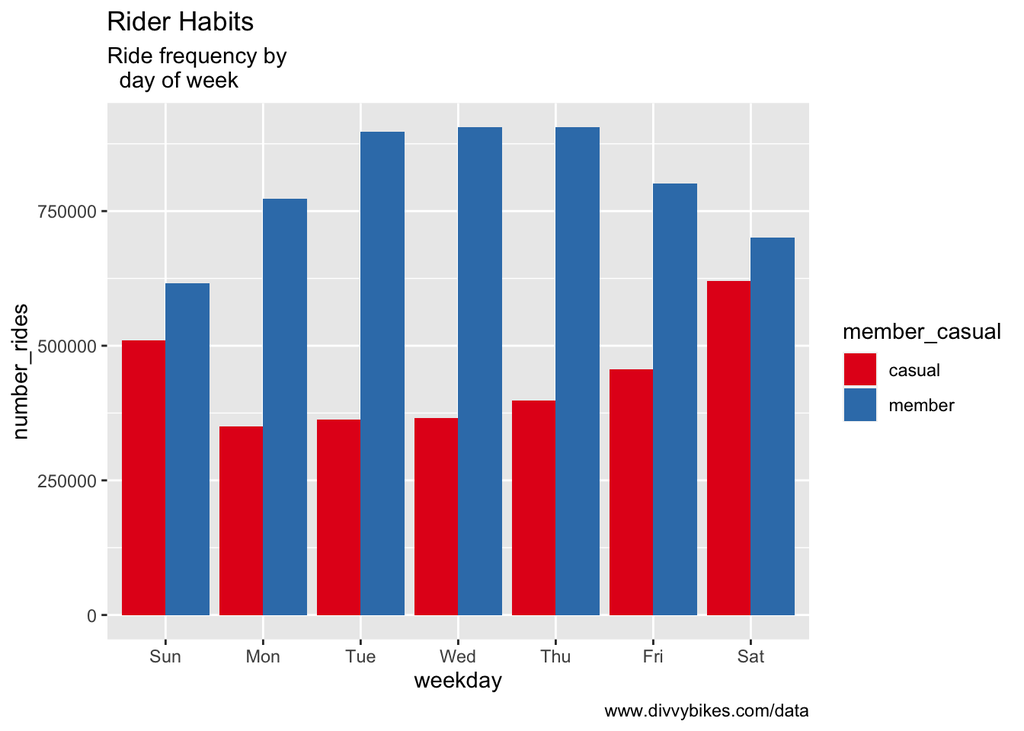

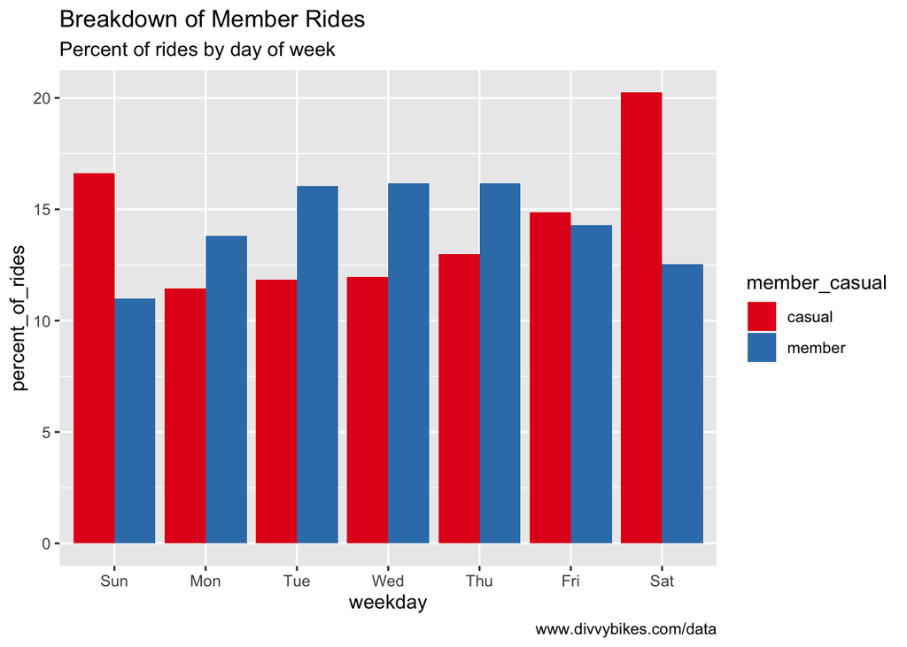

```r
## Create plot to analyze number of rides by weekday, for member_casual
comb_tripdata_2023_cleaned %>%
  mutate(weekday = wday(started_at, label = TRUE)) %>% #create weekday field
  group_by(member_casual, weekday) %>%  # group by usertype and weekday
  summarize(number_rides = n(), average_duration = mean(trip_duration)) %>%
  # num of rides & avg duration
  arrange(member_casual, weekday) %>%  # arrange
  ggplot() + geom_col(mapping = aes(x = weekday, y = number_rides, fill = member_casual),
  position = "dodge") + labs(title = "Rider Habits", subtitle = "Ride frequency by
  day of week", caption = "www.divvybikes.com/data") +
  scale_fill_brewer(palette = "Set1")
  # column plot num rides v weekday, adjusted color

## Analyze & plot the percentage of rides by weekday by member type
comb_tripdata_2023_cleaned %>%
  mutate(weekday = wday(started_at, label = TRUE)) %>% # create weekday field
  group_by(member_casual, weekday) %>% # group by member type & weekday
  summarise(count=n()) %>% #count the number of each type of member
  mutate(percent_of_rides = count/sum(count) *100) %>% # Calculate percent rides by weekday
  arrange(member_casual, weekday) %>% # arrange
  ggplot() + geom_col(mapping = aes(x = weekday, y = percent_of_rides,
  fill = member_casual), position = "dodge") + labs(title = "Breakdown of Member Rides", subtitle = "Percent of rides by day of week", caption = "www.divvybikes.com/data") + scale_fill_brewer(palette = "Set1")
  # plot percent of rides by weekday for each type of member v season, adjust color
```

**Key Finding #1**

- The plot on the left shows that casual riders prefer to ride on weekend days whereas members tend to ride more during the week.
- More casual rides occur on Saturday than any other day of the week and more member rides occur between Tuesday and Thursday than any other days of the week.
- The plot on the right shows that, although more members ride on any given day of the week, when compared to casual riders, a greater percentage of casual riders ride from Friday through Sunday.
- Slightly over 50% of all casual rides occur on the weekend (Fri.-Sun.) compared to only 36.9% of member rides.

**Takeaway** Casual riders tend to ride more on weekend days suggesting that incentives should be targeting casual weekend riders. Possible incentives might include lowering the per minute cost of weekend rides, currenlty set at $0.18/min. (classic bike), for a set time period for anyone purchasing a new membership. Additionally, new members might receive a limited number of guest passes that may only be used on weekend days.

### Plot Showing Median Ride Duration by Weekday for Member Type

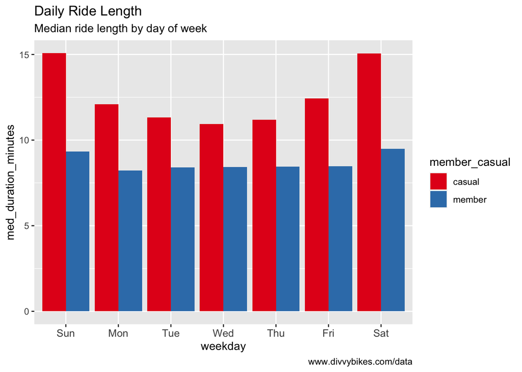

```r
## Create plot to analyze median ride duration by weekday, for member_casual
comb_tripdata_2023_cleaned %>%
  mutate(weekday = wday(started_at, label = TRUE)) %>% # create weekday field
  group_by(member_casual, weekday) %>%  # group by usertype and weekday
  summarize(number_rides = n(), med_duration_minutes = median(trip_duration)) %>%
  # num of rides & median ride duration
  arrange(member_casual, weekday) %>%  # arrange
  ggplot() + geom_col(mapping = aes(x = weekday, y = med_duration_minutes,
  fill = member_casual), position = "dodge") + labs(title = "Daily Ride Length",
  subtitle = "Median ride length by day of week", caption = "www.divvybikes.com/data") +
  scale_fill_brewer(palette = "Set1") + theme(axis.text.x = element_text(size = 10))
```

```r
  # column plot median ride duration v weekday, adjusted color
```

**Key Finding #2**

- The plot shows that casual riders take longer rides on Saturdays and Sundays.
- Length of rides for casual riders falls toward the middle of the week and then begins to increase again moving toward the weekend.
- Members ride lengths remain consistent throughout the week with a slight increase in ride length on Saturdays and Sundays.

**Takeaway** Look to incentivize longer rides on weekends, with the purchase of a new membership. In 2023 alone, close to 100,000 weekend rides (Fri.-Sun.) were taken, by casual riders that lasted longer than 45 minutes. Members are currently charged $0.18/minute (classic bike) for rides lasting over 45 minutes. One incentive might be to extend the length of the free ride time to 60 minutes for new members allowing them to ride longer on the weekend. Additionally, new members could receive bonus points for participating in the Bike Angels program on weekend days and use those points toward purchasing extra riding minutes, DIVVY swag, discounted rates on scooters and e-bikes, or reduced membership renewal costs.

### Plot Showing Number of Rides & Trip Duration by Time of Day for Member Type

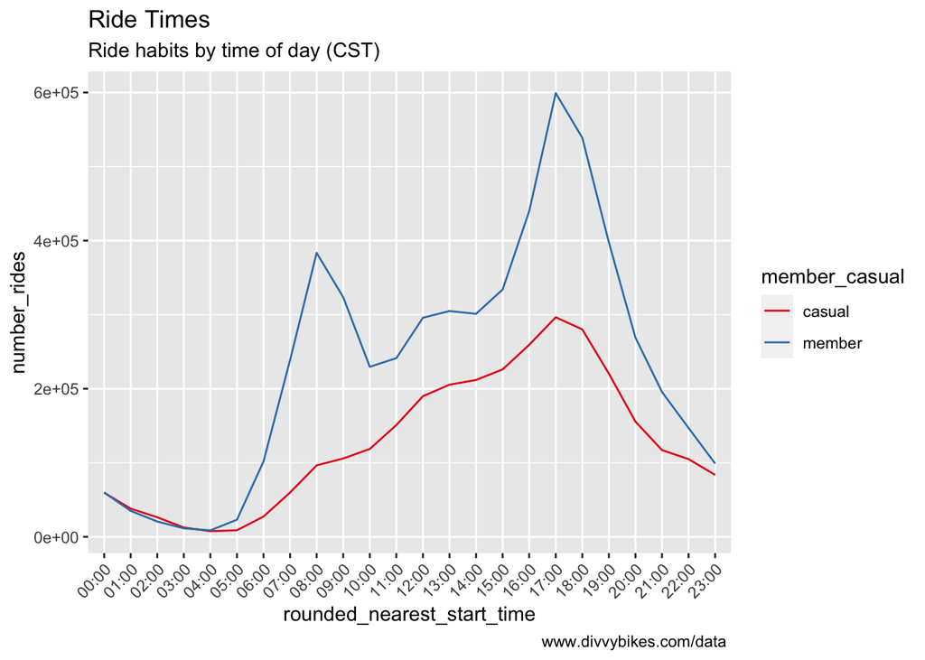

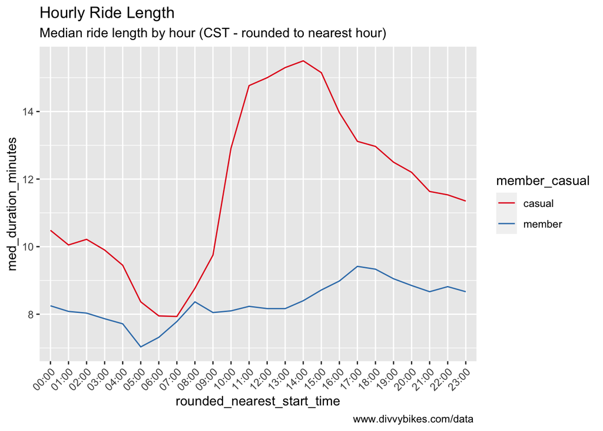

```r
comb_tripdata_2023_cleaned %>%
  group_by(member_casual, rounded_nearest_start_time) %>% # group by member_casual & time
  summarize(number_rides = n(), avg_trip_duration = mean(trip_duration)) %>%
  # num of rides and median trip duration
  arrange(member_casual, rounded_nearest_start_time) %>% # arrange member_casual & time
  ggplot() + geom_line(mapping = aes(x = rounded_nearest_start_time, y = number_rides,
  group = member_casual, color = member_casual)) + labs(title = "Ride Times", subtitle = "Ride habits by time of day (CST)", caption = "www.divvybikes.com/data ") +
  scale_color_brewer(palette = "Set1") + theme(axis.text.x = element_text(angle = 45, hjust = 1))
  # line plot of number of rides by time of day by member type

## Analyze and plot ride duration by time of day
comb_tripdata_2023_cleaned %>%
  group_by(member_casual, rounded_nearest_start_time) %>% # group by member_casual & time
  summarize(number_rides = n(), med_duration_minutes = median(trip_duration)) %>%
  # num of rides and median trip duration
  arrange(member_casual, rounded_nearest_start_time) %>% # arrange member_casual & time
  ggplot() + geom_line(mapping = aes(x = rounded_nearest_start_time, y = med_duration_minutes,
  group = member_casual, color = member_casual)) + labs(title = "Hourly Ride Length",
  subtitle = "Median ride length by hour (CST - rounded to nearest hour)",
  caption = "www.divvybikes.com/data ") + scale_color_brewer(palette = "Set1") + theme(axis.text.x = element_text(angle = 45, hjust = 1))
  # line plot of number of rides by time of day by member type
```

**Key Finding #3**

- The plot on the left shows the number of casual rides, occurring on any given day, is highest between the hours of 4pm and 6pm (CST).
- The number of member rides spikes between the hours of 7am and 10am and then again between the 4pm and 7pm (CST).
- The plot on the right indicates that the length of casual rides dramatically increases between the hours of 9am and 11am (CST).
- Casual riders ride for longer periods of time between the hours of 11am and 3pm (CST). It is during this period of time that casual rider ride times peak for the day.
- Member ride lengths are much more consistent throughout the course of the day, with the longest rides occurring between the hours of 4pm and 7pm (CST).

**The Business Task:** Design marketing strategies aimed at converting casual riders into annual members.

**Questions to be answered from analysis:** How do annual members and casual riders use Cyclistic bikes differently?

**Marketing strategy recommendations aimed at converting casual riders into annual members:** Recommendations are based on these findings:

- Casual riders ride more frequently on weekend days (Friday - Sunday) and daily between the hours of 4pm and 6pm.
- Casual riders ride for longer periods of time on weekend days (Friday - Sunday) and daily between the hours of 11am and 3pm.